# Snowshoe Hares Exploratory Report

Alison Sells

11/18/2020

### 1.Introduction

This report provides and exploratory overview of differences in juvenile hare weights between from three grid sites in the Bonanza Creek Experimental Forest from 1999 to 2012(Kielland et. al 2017). Specifically, weights, and hind lengths are explored and compared across the male, female and unidentified hares. To explore this dataset multiple methods of visualization are used in preparation to run statistical tests to determine the correlation between the various variables that are being observed. The study takes place in the Bonanza Creek Experimental Forest which is in Fairbanks Alaska.

### 2.Data and Analyses

This data was collected from the Bonanza Creek Experimental Forest in Fairbanks Alaska form 1999 to 2012. It was collected by using three grid sites to see the variation of many variables including weight, hindfoot length, as well as the concentration of hares captured at different grid sites. This report will use various methods of visualization including a histograms,boxplots, and tables; and will utilize t tests, and a linear regression model to look at significance levels and residual impacts. All analyses are in R version 4.0.2 using RStudio version 1.3.1056.

### 3.Exploratory Findings

#### A. Annual juvenile hare trap counts

Juvenile hare trappings were totaled annually from 1999 to 2012

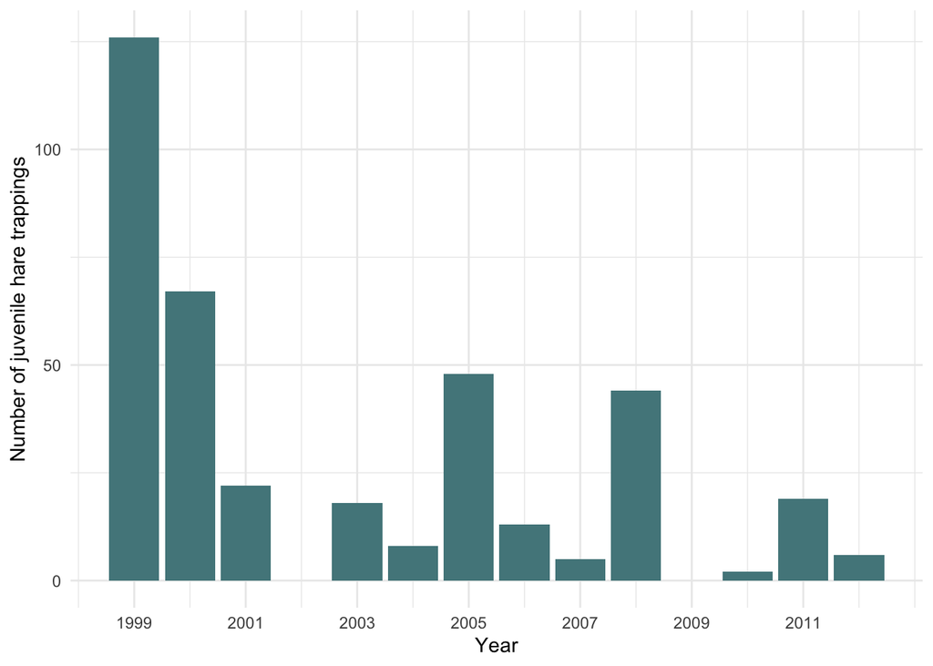

**Figure 1.** Graph detailing the total number of hare trappings within the Bonanza Creek Experimental Forest during 1999-2012,Fairbanks Alaska from Kielland et. al(2017)

#### B. Visualize juvenile hare weights

The following visualization aims to explore the relationships between juvenile hare weights as related to sex and the grid site of capture.

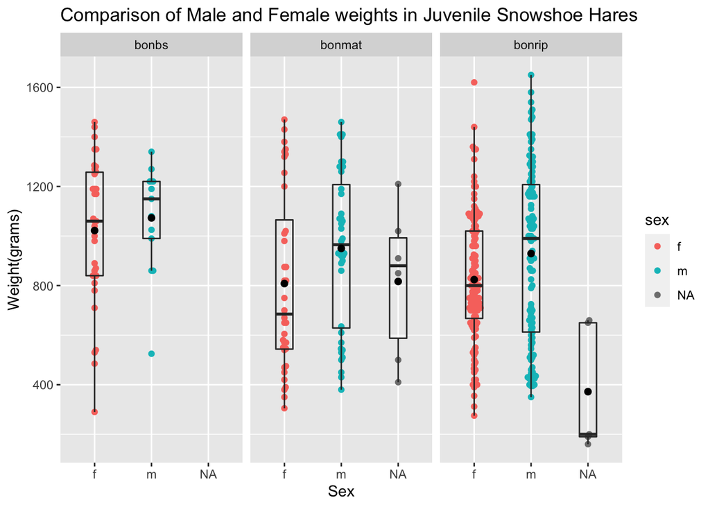

**Figure 2.** Hare weight observations (grams) for male, female and unidentified juvenile snowshoe hares from sites Bonanza Balck Spruce (bonbs),Bonanza Mature(bonmat), and Bonanza Riparian(bonrip).Coral (female), Teal(male), and Gray(N/A) represent individual observations for a juvenile hare’s weight. Box endpoints indicate the 25th and 75th percentile values; the black line and black point within the box indicate the median and mean value for each sex, respectively.Data: Kielland et al(2017)

#### C. Juvenile weight comparison between male and female snowshoe hares

The following will be a deeper exploration of the Juvenule weight comparison within the snowshoe hare sample

**Table 1.** Descriptive statistics (mean, standard deviation, and sample size) for three grid sites of Juvenile Snowshoe Hares. Data: Kielland et. al(2017)

| Sex | Mean weight (grams) | Standard deviation (grams) | Sample size |
| --- | --- | --- | --- |
| f | 1022.06 | 292.96 | 35 |
| f | 808.19 | 361.12 | 36 |
| f | 824.15 | 255.04 | 129 |
| m | 1073.08 | 222.64 | 13 |
| m | 950.12 | 314.69 | 40 |
| m | 929.27 | 349.17 | 110 |
| NA | NaN | NA | 1 |
| NA | 816.67 | 307.09 | 7 |
| NA | 372.00 | 258.79 | 7 |

#### Major Takeaways

After running a t test and a chon’s d test, the difference in mean weights between male and female hares is approximately 90 grams with a cohen’s D estimate of 0.29. The outcome of the two sample t tests revealed a p value of 0.007 which indicates a very low probability that these samples were taken with populations with the same mean. Although p values are not the stand alone metric of significance, that combined with the low Cohen’s D score help lead to a statement that it is extremely unlikely that these samples came from populations with the same mean weights.

#### D. Relationship between juvenile weight and hind foot length

The following will explore the relationship between juvenile weight and hind foot length in the snowshoe hare population

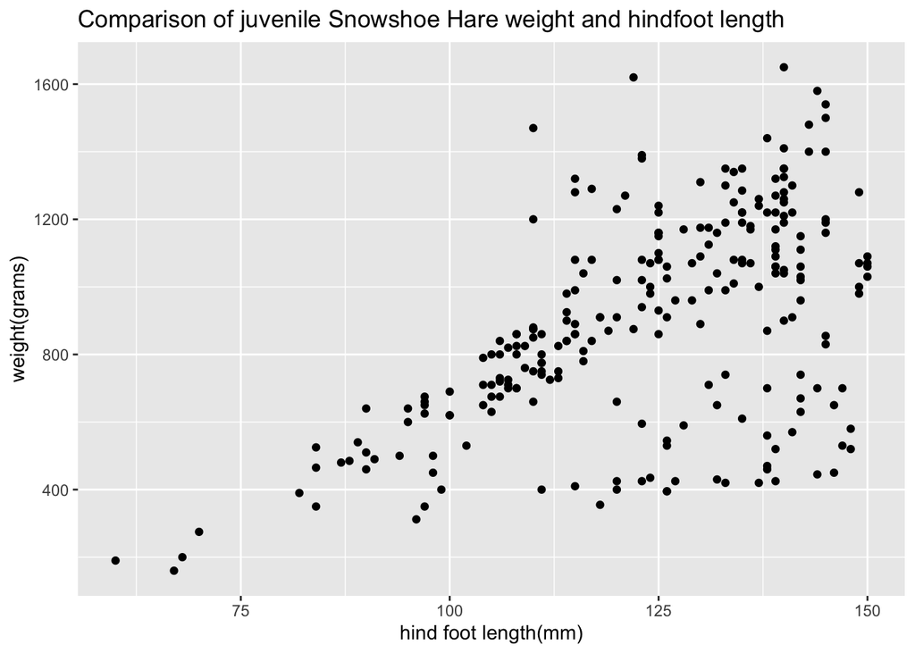

**Figure 3.** Comparison of juvenile hare weights and hinndfoot measurements from all of the juvenile hares within the sample.Each dot represents an individual observation for a juvenile hare’s weight and hindfoot measurement. Data: Kielland et al(2017)

#### Linear Regression

The following will be a linear regression of the juvenile hares data to test further the relationship between hindfoot length and weight.

[figure not shown]

**Figure 4.** Linear Regression model Comparing juvenile hare weights and hinndfoot measurements from all of the juvenile hares within the sample.Each dot represents an individual observation for a juvenile hare’s weight and hindfoot measurement. Data: Kielland et al(2017)

With a R squared value of .2959, this indicates that 29 percent on the juvenille’s hare weight is determined by their hindfoot length in millimeters. However, this figure is a little concerning when one considers the assumptions needed for the linear regression to show the data. The assumption of the data being relatively linear is concerning because of the concentration of data points between 100 and 150 mm and the lack of data where the hares’ hindfoot length is less than 100 mm. ALso this model simplifies the relationship between tese two variables, and does not consider anything else that could describe the relationship.

### 5. Citations

Kielland, K., F.S. Chapin, R.W. Ruess, and Bonanza Creek LTER. 2017. Snowshoe hare physical data in Bonanza Creek Experimental Forest: 1999-Present ver 22. Environmental Data Initiative. https://doi.org/10.6073/pasta/03dce4856d79b91557d8e6ce2cbcdc14